# ALGORITMA FUZZY C-MEANS DENGAN R

Annisa Suherman-Institut Teknologi Statistika dan Bisnis Muhammadiyah Semarang

2023-01-21

# Pengertian Analisis Cluster

Clustering merupakan salah satu metode machine learning dan termasuk dalam unsupervised learning. Unsupervised learning adalah metode machine learning dimana dalam data yang akan dianalisis tidak terdapat target variabel. Dalam unsupervised learning lebih fokus dalam melakukan eksplorasi data seperti mencari pola dalam data. Clustering sendiri bertujuan dalam mencari pola data yang mirip sehingga memiliki kemungkinan dalam mengelompokkan data-data yang mirip tersebut. Dalam yang telah dikelompokkan dalam clusterung biasanya disebut juga sebagai cluster. Dalam menentukan cluster yang baik adalah ketika suatu anggota dalam cluster memiliki kemiripan semirip mungkin sedangkan antar anggota cluster memiliki perbedaan yang cukup signifikan. Clustering banyak digunakan dalam berbagai bidang seperti segmentasi customer, rekomendasi produk, profiling data, dan masih banyak lagi.

# Algoritma Fuzzy C-Means

Fuzzy C-Means (FCM) adalah Teknik clustering yang digunakan untuk pengelompokan data yang tidak hanya memiliki nilai yang sama didalam suatu cluster, tetapi juga kelompok nilai-nilai yang memiliki dua atau lebih kelompok menurut level keanggotaannya.

FCM termasuk kedalam soft clustering karena penentuan keanggotaannya berdasarkan derajat keanggotaan.

# Tahapan Algoritma Fuzzy C-Means

1. Input data
2. Inisialisasi, menentukan : a)Jumlah Cluster ( k ≥ 2 ); b)Bobot pangkat (w > 1 ); c)Jumlah maksimal Iterasi; d)Ambang batas perubahan nilai fungsi objektif (Error terkecil yang diharapkan).
3. Inisialisasi Matriks Pseudo-Partition Memberikan nilai secara acak pada matriks Fuzzy Pseudo partition dengan syarat antara u (u1) , i (u2) dan j (u3) berjumlah satu, Σuij = 1

$$\sum_{j=1}^k u_{i j}=1$$

4. Pengulangan Lakukan langkah u1*(a1), u1*(a2), u1*(a3), u1*(a4) u2*(a1), u2*(a2), u2*(a3), u2*(a4) Pengulangan akan tetap berlanjut apabila : a)Perubahan pada nilai fungsi objektif masih di atas nilai ambang batas yang di tentukan ; atau b) perubahan pada nilai centroid masih di atas nilai ambang yang di tentukan ; atau c) Iterasi maksimal belom tercapai.
5. Hitung nilai centroid dari setiap cluster menggunakan persamaan:

$$C_{i j}=\frac{\sum_{i=1}^N\left(U_{i j}\right)^w X_{i j}}{\sum_{i=1}^N\left(U_{i j}\right)^w}$$

6. Hitung ulang matriks fuzzy pseudo-partition (derajat keanggotaan setiap data pada setiap cluster) menggunakan persamaan :

$$U_{i j}=\frac{D\left(x_i, c_j\right)^{\frac{-2}{w-1}}}{\sum_{i=1}^k D\left(x_i, c_j\right)^{\frac{-2}{w-1}}}$$

# Eksperimen Algoritma Fuzzy C-Means

## Library

Sebelum memasukkan data, kita perlu memanggil library terlebih dahulu dan meng install beberapa packages yang belum tersedia.

```r
require(ppclust)
require(factoextra)
require(dplyr)
require(cluster)
require(fclust)
```

## Input Dataset

Untuk variabel 1 Gender, 1 = Laki-laki, 0 = Perempuan.

Untuk variabel 6 Result, 1 = Terkena anemia, 0 = Tidak terkena anemia.

```r
library(readxl)
anemia <- read_excel("anemia.xlsx", col_types = c("numeric",
    "numeric", "numeric", "numeric", "numeric",
    "numeric"))
```

Selanjutnya menampilkan data set.

```r
anemia
```

| Gender | Hemoglobin | MCH | MCHC | MCV | Result |
| --- | --- | --- | --- | --- | --- |
| 1 | 14.9 | 22.7 | 29.1 | 83.7 | 0 |
| 0 | 15.9 | 25.4 | 28.3 | 72.0 | 0 |
| 0 | 9.0 | 21.5 | 29.6 | 71.2 | 1 |
| 0 | 14.9 | 16.0 | 31.4 | 87.5 | 0 |
| 1 | 14.7 | 22.0 | 28.2 | 99.5 | 0 |
| 0 | 11.6 | 22.3 | 30.9 | 74.5 | 1 |
| 1 | 12.7 | 19.5 | 28.9 | 82.9 | 1 |
| 1 | 12.7 | 28.5 | 28.2 | 92.3 | 1 |
| 0 | 14.1 | 29.7 | 30.5 | 75.2 | 0 |
| 1 | 14.9 | 25.8 | 31.3 | 82.9 | 0 |

[output cut: 1411 more lines]

Kemudian menghapus Variabel kolom pertama karena variabel gender tidak diperlukan. Dari data anemia ini kita hanya akan tampilkan n=50 dari 1421.

```r
x=anemia[,-1]
x[1:50,]
```

| Hemoglobin | MCH | MCHC | MCV | Result |
| --- | --- | --- | --- | --- |
| 14.9 | 22.7 | 29.1 | 83.7 | 0 |
| 15.9 | 25.4 | 28.3 | 72.0 | 0 |
| 9.0 | 21.5 | 29.6 | 71.2 | 1 |
| 14.9 | 16.0 | 31.4 | 87.5 | 0 |
| 14.7 | 22.0 | 28.2 | 99.5 | 0 |
| 11.6 | 22.3 | 30.9 | 74.5 | 1 |
| 12.7 | 19.5 | 28.9 | 82.9 | 1 |
| 12.7 | 28.5 | 28.2 | 92.3 | 1 |
| 14.1 | 29.7 | 30.5 | 75.2 | 0 |
| 14.9 | 25.8 | 31.3 | 82.9 | 0 |

[output cut: 40 more lines]

## Pra-pemrosesan Data

Sebelum data diproses kita perlu memeriksa apakah ada nilai yang hilang dengan menggunakan fungsi colSums().

```r
colSums(is.na(x))
```

```
## Hemoglobin        MCH       MCHC        MCV     Result
##          0          0          0          0          0
```

Dapat dilihat bahwa tidak ada nilai yang hilang. Jadi, kita tidak perlu Pra-pemrosesan lebih lanjut.

## Summary of Data

Di sini, di bawah ini adalah ringkasan variabel dari data set anemia. Di mana, minimum, maksimum, median, dan rata-rata, kuartil 1 dan kuartil 3 dihitung untuk setiap variabel dan ditampilkan.

```r
summary(x)
```

```
##    Hemoglobin         MCH             MCHC            MCV
##  Min.   : 6.60   Min.   :16.00   Min.   :27.80   Min.   : 69.40
##  1st Qu.:11.70   1st Qu.:19.40   1st Qu.:29.00   1st Qu.: 77.30
##  Median :13.20   Median :22.70   Median :30.40   Median : 85.30
##  Mean   :13.41   Mean   :22.91   Mean   :30.25   Mean   : 85.52
##  3rd Qu.:15.00   3rd Qu.:26.20   3rd Qu.:31.40   3rd Qu.: 94.20
##  Max.   :16.90   Max.   :30.00   Max.   :32.50   Max.   :101.60
##      Result
##  Min.   :0.0000
##  1st Qu.:0.0000
##  Median :0.0000
##  Mean   :0.4363
##  3rd Qu.:1.0000
##  Max.   :1.0000
```

## Korelasi

Tahap ini untuk mengetahui korelasi antar variabel.

```r
cor(x)
```

```
##             Hemoglobin         MCH        MCHC         MCV      Result
## Hemoglobin  1.00000000  0.01408126 -0.04259699 -0.02588463 -0.79626101
## MCH         0.01408126  1.00000000  0.01879519 -0.01594830 -0.02867752
## MCHC       -0.04259699  0.01879519  1.00000000  0.06845045  0.04806695
## MCV        -0.02588463 -0.01594830  0.06845045  1.00000000 -0.02057051
## Result     -0.79626101 -0.02867752  0.04806695 -0.02057051  1.00000000
```

```r
require(psych)
```

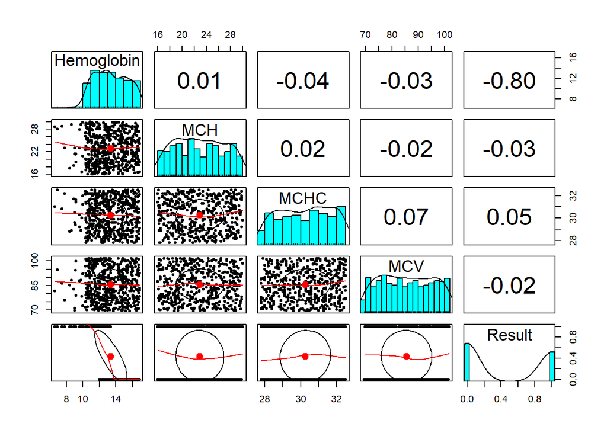

```r
pairs.panels(x, method = "pearson")
```

## Fuzzy Membership Matrix

Fuzzy C-Means (FCM) ini didasarkan pada Teori Logika Fuzzy (Lotfi Zadeh-1965) Keanggotaan data tidak harus bernilai 0 dan 1, tetapi dengan nilai derajat keanggotaannya berada di jangkauan antara 0 sampai 1.

0 = sama sekali bukan anggota; 1 = anggota secara penuh.

“Semakin tinggi nilai keanggotaan, semakin tinggi pula derajatnya.”

### Pembagian Cluster/kelompok = 3

```r
res.fcm <- fcm(x, centers=3)
```

Menampilkan Cluster/kelompok

```r
as.data.frame(res.fcm$u)[1:50,]
```

|  | Cluster 1 | Cluster 2 | Cluster 3 |
| --- | --- | --- | --- |
| 1 | 0.883414217 | 0.07842778 | 0.038158001 |
| 2 | 0.106394581 | 0.86112636 | 0.032479060 |
| 3 | 0.119351172 | 0.84049216 | 0.040156672 |
| 4 | 0.553503255 | 0.17134201 | 0.275154736 |
| 5 | 0.060811639 | 0.01960493 | 0.919583427 |
| 6 | 0.031966809 | 0.95997821 | 0.008054985 |
| 7 | 0.689098648 | 0.22334663 | 0.087554727 |
| 8 | 0.426405099 | 0.08810919 | 0.485485706 |
| 9 | 0.246648884 | 0.68582649 | 0.067524621 |
| 10 | 0.795692657 | 0.14643483 | 0.057872510 |

[output cut: 40 more lines]

### Matriks prototypes cluster awal dan akhir

```r
res.fcm$v0
```

```
##           Hemoglobin  MCH MCHC  MCV Result
## Cluster 1       14.0 27.4 31.8 87.2      0
## Cluster 2       12.8 22.9 28.8 72.0      0
## Cluster 3       10.8 17.5 29.3 95.8      1
```

```r
res.fcm$v
```

```
##           Hemoglobin      MCH     MCHC      MCV    Result
## Cluster 1   13.39443 23.66008 30.10574 85.54657 0.4104841
## Cluster 2   13.44944 22.57629 30.20883 74.53194 0.4620961
## Cluster 3   13.40115 22.41175 30.42231 96.96000 0.4180492
```

```r
summary(res.fcm)
```

[output not shown]

[output cut: 53 more lines]

```
##
## Dunn's Fuzziness Coefficients:
## dunn_coeff normalized
##  0.6325960  0.4488939
##
## Within cluster sum of squares by cluster:
##        1        2        3
## 13914.23 16330.89 14600.97
## (between_SS / total_SS =  73.01%)
##
## Available components:
##  [1] "u"          "v"          "v0"         "d"          "x"
##  [6] "cluster"    "csize"      "sumsqrs"    "k"          "m"
## [11] "iter"       "best.start" "func.val"   "comp.time"  "inpargs"
## [16] "algorithm"  "call"
```

## FCM dengan Multiple Start

Fungsi fcm dapat dimulai beberapa kali Untuk menemukan solusi optimal.

```r
res.fcm <- fcm(x, centers=3, nstart=5)

res.fcm$func.val
```

```
## [1] 31100.48 31100.48 31100.48 31100.48 31100.48
```

```r
res.fcm$iter
```

```
## [1] 66 56 68 61 66
```

```r
res.fcm$best.start
```

```
## [1] 1
```

```r
summary(res.fcm)
```

[output not shown]

[output cut: 53 more lines]

```
##
## Dunn's Fuzziness Coefficients:
## dunn_coeff normalized
##  0.6325960  0.4488939
##
## Within cluster sum of squares by cluster:
##        1        2        3
## 13914.23 16330.89 14600.97
## (between_SS / total_SS =  73.01%)
##
## Available components:
##  [1] "u"          "v"          "v0"         "d"          "x"
##  [6] "cluster"    "csize"      "sumsqrs"    "k"          "m"
## [11] "iter"       "best.start" "func.val"   "comp.time"  "inpargs"
## [16] "algorithm"  "call"
```

## Visualization

Plotcluster() dapat digunakan untuk memplot hasil pengelompokan. Ada beberapa Plot yaitu sebagai berikut:

### Pairwise Scatter Plots

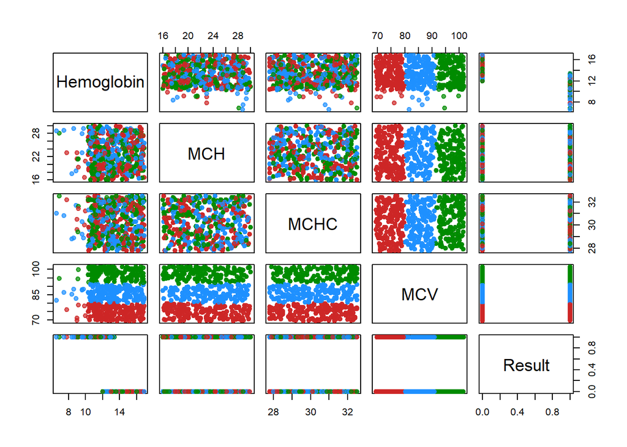

```r
plotcluster(res.fcm, cp=1, trans=TRUE)
```

### Cluster Plot with fviz_cluster

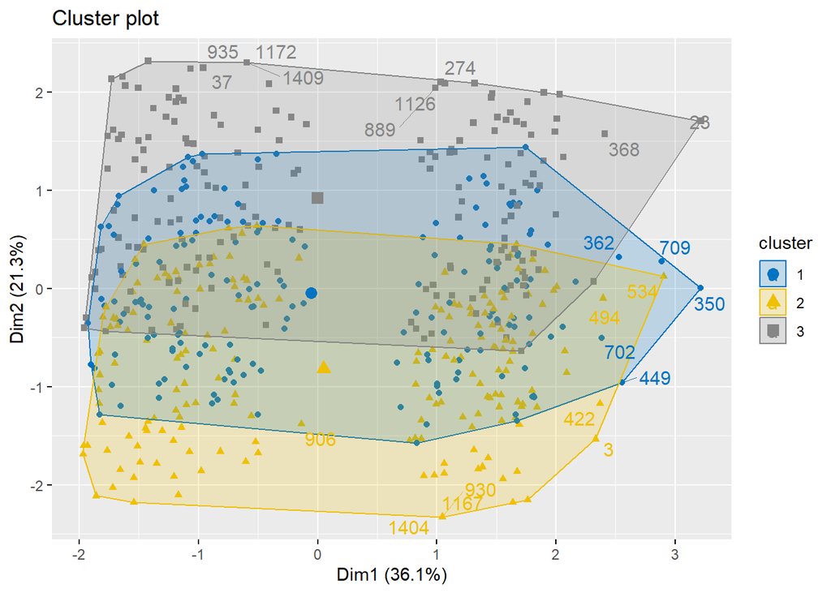

```r
res.fcm2 <- ppclust2(res.fcm, "kmeans")
fviz_cluster(res.fcm2, data = x,
  ellipse.type = "convex",
  palette = "jco",
  repel = TRUE)
```

### Cluster Plot with clusplot

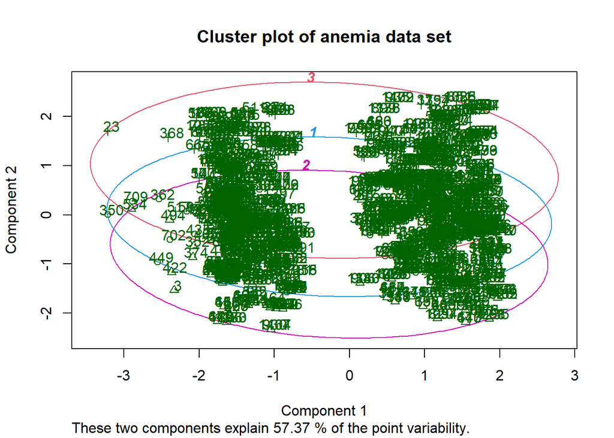

```r
res.fcm3 <- ppclust2(res.fcm, "fanny")

cluster::clusplot(scale(x), res.fcm3$cluster,
  main = "Cluster plot of anemia data set",
  color=TRUE, labels = 2, lines = 2, cex=1)
```

## Validation of Results

Tahap ini merupakan proses evaluasi terhadap hasil clustering. Disini terdapat Partition Entropy (PE), Partition Coefficient (PC) dan Modified Partition Coefficient (MPC) dan Fuzzy Silhouette Index.

```r
res.fcm4 <- ppclust2(res.fcm, "fclust")
idxsf <- SIL.F(res.fcm4$Xca, res.fcm4$U, alpha=1)
idxpe <- PE(res.fcm4$U)
idxpc <- PC(res.fcm4$U)
idxmpc <- MPC(res.fcm4$U)

cat("Partition Entropy: ", idxpe)
```

```
## Partition Entropy:  0.6471561
```

```r
cat("Partition Coefficient: ", idxpc)
```

```
## Partition Coefficient:  0.632596
```

```r
cat("Modified Partition Coefficient: ", idxmpc)
```

```
## Modified Partition Coefficient:  0.4488939
```

```r
cat("Fuzzy Silhouette Index: ", idxsf)
```

```
## Fuzzy Silhouette Index:  0.6497773
```

# Referensi

1. https://rpubs.com/rahulSaha/Fuzzy-CMeansClustering
2. https://rpubs.com/writetosamadalvi/Fuzzy
3. https://github.com/annisashrmn22/Algoritma-Fuzzy-C-Means
4. https://drive.google.com/drive/folders/13VrpoyFvsWTQ_6rc5Ivy1A3xm8Y4TIP9